# Testing of the Ellipsometry Models

*19/01/2024*

- It seems that there are some issues with processing the ellipsometry models that are either due to the software terminology or my own fitting parameters, and it is not exactly clear which side of the coin is the problem.
- The ellipsometry software calls certain models in different ways and brings through parameters that are not as clear as one would like.
- Similarly, the depth of ellipsometry knowledge available is quite vast, and finding the finer details is not as easy as one might think.
- So let's work through what we can and see what the best approach is going forward.
- The data taken here is from the most recent trip to Sheffield to use the VASE system there, on the 14/12/2023.
- I will just include the model parameters directly into the code to make things very simple, and these can later be put into functions to fit the code.

## Sam's Data

- Sam gave me three samples of ITO on different substrates and of different thicknesses.
- The three samples also had different deposition conditions, and are therefore assumed to have different refractive indices and structural compositions.
- As such, the three samples were fitted with different models, which I thought were perhaps the most appropriate at the time, although this may turn out to be untrue.

```python
import numpy as np
import scipy.constants as const
import matplotlib.pyplot as plt
```

### AS5

- Sample AS5 was a simple Cauchy model fitted to a layer of ITO of approximately 250nm.
- This was perhaps not the best way to fit this layer, but at least the refractive index can maybe be known.
- Below is the fitting:

```python
A = 1.706
B = 0.08153
C = -0.00335
wavelength_range = range(400, 1001, 1)
wavelength_m = [x * 1E-9 for x in wavelength_range]
n = [A + (B / (x ** 2)) + (C / (x ** 4)) for x in wavelength_range]
n_m = [A + (B / (x ** 2)) + (C / (x ** 4)) for x in wavelength_m]
print(n)
print(n_m)
```

```
[1.7060005095623691, 1.7060005070240805, 1.7060005045047106, 1.7060005020040723, 1.70600049952198, 1.7060004970582507, 1.706000494612704, 1.7060004921851613, 1.7060004897754462, 1.7060004873833847, 1.7060004850088046, 1.7060004826515363, 1.7060004803114115, 1.7060004779882647, 1.706000475681932, 1.7…
[-1.308593749994904e+23, -1.295589192450721e+23, -1.2827457803462695e+23, -1.2700611234164811e+23, -1.257532872658065e+23, -1.2451587195174754e+23, -1.2329363950968214e+23, -1.2208636693772634e+23, -1.2089383504594861e+23, -1.1971582838208127e+23, -1.1855213515885787e+23, -1.174025471829351e+23, -1.…
```

- So we see that the cauchy model seems to work well when the wavelength is kept in nm notation, i.e., not put into standard units.
- Why is that? Are the parameters A, B, and C already formed for this unit? Are they perhaps in energy units and would it look even better if we convert A, B, and C into wavelength units, or the wavelength range in to eV?
- To convert wavelength into energy, we use the following equation:

$$E=hc/\lambda$$

- and:

$$eV=E/e$$

- Where h, c, and e have their usual notation, $\lambda$ is wavelength, E is energy in joules, and eV is the energy in electronvolts.

```python
A_m = (const.h * const.speed_of_light) / (A * const.elementary_charge)
B_m = (const.h * const.speed_of_light) / (B * const.elementary_charge)
C_m = (const.h * const.speed_of_light) / (C * const.elementary_charge)
print(A_m, B_m, C_m)
n_converted = [A_m + (B_m / (x ** 2)) + (C_m / (x ** 4)) for x in wavelength_range]
n_converted_m = [A_m + (B_m / (x ** 2)) + (C_m / (x ** 4)) for x in wavelength_m]
print(n_converted)
print(n_converted_m)
energy_range = [(const.h * const.speed_of_light) / x for x in wavelength_m]
eV_range = [E / const.elementary_charge for E in energy_range]
n_E = [A + (B / (x ** 2)) + (C / (x ** 4)) for x in eV_range]
print(n_E)
```

```
7.267538008980086e-07 1.5207187346154822e-05 -0.00037010208487522466
[7.268488313618095e-07, 7.268483580570473e-07, 7.26847888279306e-07, 7.268474219936297e-07, 7.268469591654952e-07, 7.268464997608045e-07, 7.26846043745879e-07, 7.26845591087453e-07, 7.268451417526684e-07, 7.268446957090677e-07, 7.268442529245885e-07, 7.268438133675584e-07, 7.268433770066883e-07, 7.2…
[-1.4457112690438366e+22, -1.4313440634916236e+22, -1.4171548885758666e+22, -1.4031411035739236e+22, -1.3893001133484356e+22, -1.3756293674502067e+22, -1.3621263592409098e+22, -1.3487886250351067e+22, -1.3356137432611356e+22, -1.3225993336403863e+22, -1.309743056384535e+22, -1.2970426114102847e+22, …
[1.7144497409026245, 1.7144918598180432, 1.714534082073299, 1.7145764076547314, 1.7146188365486454, 1.714661368741312, 1.7147040042189683, 1.7147467429678176, 1.714789584974029, 1.7148325302237375, 1.7148755787030439, 1.7149187303980153, 1.7149619852946851, 1.7150053433790517, 1.7150488046370802, 1.…
```

- Ok, so converting A, B, and C into standard units has not produced realistic values, but converting the wavelength parameter into electronvolts, did seem to produce very similar numbers as we got by doing the calculation with wavelength in nm.
- Why is that the case?
- Let's see how they look when they're compared to each other.

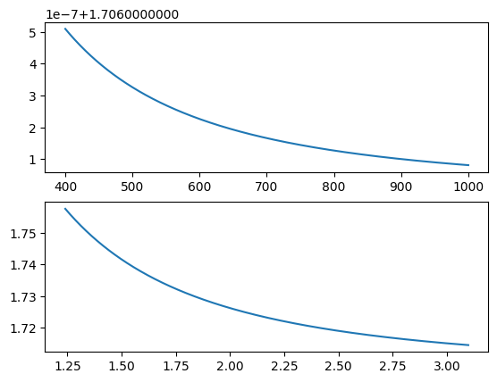

```python
fig, (ax1, ax2) = plt.subplots(2)
ax1.plot(wavelength_range, n)
ax2.plot(eV_range, n_E)
plt.show()
```

- The top graph looks very much like it did in the one I produced for Sam, but the second graph looks more believable as a dispersion.
- The variation in refractive index is not unexpected from a dispersion curve and is well within the bounds I would expect for ITO.
- So why is that? Well let's take a quick look at the Cauchy model and figure it out.
- In optics, Cauchy's transmission equation is an empirical relationship between the refractive index and wavelength of light for a particular transparent material.
- Cauchy's equation is generally given as:

$$n(\lambda)=A+\frac{B}{\lambda^{2}}+\frac{C}{\lambda^{4}}$$

- where n is the refractive index, $\lambda$ is the wavelength, A, B, and C are the coefficients that can be determined for a material by fitting the equation to measured refractive indices at known wavelengths. The coefficients are usually quoted for $\lambda$ as the vacuum wavelength in micrometers.
- So if Cauchy's model is lined up for micrometers, what does out data look like in that unit?

```
[2.084703125, 2.0834652908028657, 2.0822302609540024, 2.0809980869325204, 2.079768818409608, 2.0785425032954308, 2.077319187784832, 2.076098916401856, 2.0748817320431425, 2.073667676020203, 2.072456788100621, 2.071249106548208, 2.0700446681621267, 2.0688435083150267, 2.067645660990212, 2.06645115881…
```

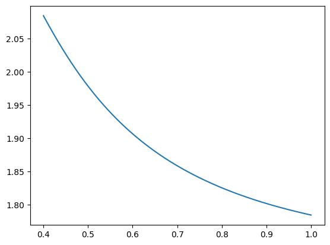

```python
wavelength_um = [x * 1E-3 for x in wavelength_range]
n_um = [A + (B / (x ** 2)) + (C / (x ** 4)) for x in wavelength_um]
print(n_um)
fig, ax = plt.subplots(1)
ax.plot(wavelength_um, n_um)
plt.show()
```

- Now that is much more like it for ITO.
- That is far closer to what the dispersion curve of ITO looks like, even the change as it approaches higher wavelength is more believable.
- Ok, so the coefficients are indeed lined up so that they are in $\mu m$.
- Make sure that this is fixed for Sam's stuff.
- The thickness measurement for AS5 was (242.23 $\pm$ 1.160)nm, which a total mean squared error of 32.863. Assuming that there is something that can be done to factor that in as some sort of error range, as well as a thickness non-uniformity of (14.07 $\pm$ 0.553)%, and the errors for A, B, and C.
- This is probably something that can be factored in at a later date. For now, just be happy that the model seems to be working.

### BI7

```python
Einf = 3.379
UV_amp = 0
UV_En = 11
IR_amp = 0
Amp = -11.88
Br = 100
En = 0.0102
rho = 0.000645
t = 6.211
mu = 0.0001
m_star = 0.5
eps_0 = 8.854E-12
```

- There are four parameters at the top of the oscillator layer parameters panel that are used to describe the real-part of the dielectric function. These include Einf, UV Pole Amplitude, UV Pole Energy, and IR Pole Amplitude:
  - Einf, or "$\varepsilon_{\infty}$", is a purely real constant added to $\varepsilon l$. $\varepsilon_{\infty}$ is often referred to in the scientific literature. "Einf = " is located at the top of the layer parameters panel.
  - Poles are equivalent to Lorentz oscillators with zero-broadening. Their position should remain outside the "fit" spectral range. As such, they only affect the real part of the dielectric function ($\varepsilon l$). They can describe dispersion created by absorptions that occur outside the measured spectral range. They are defined in the equation:

  $$\varepsilon_{pole_{n}}=\frac{Amp_{n}}{En_{n}^{2}-E^{2}}$$
  - The UV Pole (fit parameters Amp and En) and IR Pole (Fit Parameter Amp) are located immediately below "Einf = " in the layer parameters panel. They also use the Pole equation. For the IR Pole, En = 0eV always.
  - The units are ($eV$) and ($eV^{2}$) for En and Amp, respectively.
- So let's begin to build the model with what we know so far.

```python
wavelength_range = range(400, 1001, 1)
wavelength_m = [x * 1E-9 for x in wavelength_range]
energy_range = [(const.h * const.speed_of_light) / x for x in wavelength_m]
eV_range = [E / const.elementary_charge for E in energy_range]
```

- Let's first input the $\varepsilon_{\infty}$ and pole values.

```python
IR_pole = [(IR_amp) / (0 - e) for e in eV_range]
UV_pole = [(UV_amp) / (UV_En - e) for e in eV_range]
permittivity = [Einf + I + U for I, U in zip(IR_pole, UV_pole)]
print(permittivity)
```

```
[3.379, 3.379, 3.379, 3.379, 3.379, 3.379, 3.379, 3.379, 3.379, 3.379, 3.379, 3.379, 3.379, 3.379, 3.379, 3.379, 3.379, 3.379, 3.379, 3.379, 3.379, 3.379, 3.379, 3.379, 3.379, 3.379, 3.379, 3.379, 3.379, 3.379, 3.379, 3.379, 3.379, 3.379, 3.379, 3.379, 3.379, 3.379, 3.379, 3.379, 3.379, 3.379, 3.379…
```

- Now, obviously for this model, the permittivity is just $\varepsilon_{\infty}$ because the amplitudes of the IR and UV poles are 0.
- But for other models this might work a bit better.
- Now let's look at the oscillators, so Sam's material has a Harmonic and a Drude oscillator model in them.
- Harmonic:
  - The harmonic oscillator function is similar to that derived from perturbation theory in quantum mechanical treatments of single-electron transitions, and is typically written in the literature as a two-term sum. The equation is:

  $$\varepsilon_{harmonic}=\frac{Amp_{n}Br_{n}}{2}(\frac{1}{En_{n}-E-i\frac{Br_{n}}{2}}+\frac{1}{En_{n}+E-i\frac{Br_{n}}{2}})$$
  - $Amp_{n}$ approximately equals $\varepsilon_{2}$ at its peak value, and Br is approximately the full width at half-maximum (FWHM).
  - When the broadening becomes much less than the center energy ($Br_{n} \ll En$), the Harmonic oscillator is equivalent to the Lorentz function.
  - Adding an imaginary amplitude term to the Harmonic function allows $\varepsilon_{2}$ to be asymmetric around the center energy En.
  - Note however, that $\varepsilon_{2}$ becomes negative when the imaginary term iAmp is greater than zero.
  - This means that another oscillator must be added to force $\varepsilon_{2} \geq 0$ so that the total gen-osc function is Kramers-Kronig consistent.

  $$\varepsilon_{harmonic,iAmp}=\frac{[Amp_{n}+i(iAmp_{n})]Br_{n}}{2}([\Gamma(\frac{E-En_{n}}{\sigma_{n}})+\Gamma(\frac{E+En_{n}}{\sigma_n})]+i(e^{-(\frac{E-En_{n}}{\sigma_{n}})^{2}}+e^{-(\frac{E+En_{n}}{\sigma_{n}})^{2}}))$$
  - Where Amp is the amplitude, En is the center energy, and Br is the broadening.
  - The function $\Gamma$ is a convergence series that produces a Kramers-Kronig consistent line shape for $\varepsilon_{1}$.
  - $Amp_{n}$ equals $\varepsilon_{2}$ at its peak value (~$En_{n}$).
  - By defining $\sigma_{n}=\frac{Br_{n}}{2\sqrt{ln(2)}}$, $Br_{n}$ approximately equals the full width at half maximum value (FWHM).
  - Fit parameters (units): $En_{n}$ (eV), $Br_{n}$ (eV), and $Amp_{n}$ (no units).
- Drude:
  - The classic Drude model describes free carrier effects on the dielectric response.
  - Its form is equivalent to a Lorentz oscillator with center energy equal to zero.
  - There are two versions of the Drude oscillator in the gen-osc layer: Drude(RT) and Drude(NMu).
  - Drude (RT) is described by the following equation, and has a resistivity, $\rho$, and mean scattering time, $\tau$, as fit parameters.

  $$\varepsilon_{Drude(RT)}(E)=\frac{-\hbar^{2}}{\varepsilon_{0}\rho_{n}(\tau_{n} E^{2}+i\hbar E)}$$

  Where

  $$\rho=\frac{m^{*}m_{e}}{Nq^{2}\tau}=\frac{1}{q\mu N}$$
  - The physical constants are $\hbar$ (Planck's constant / $\pi$), $\varepsilon_{0}$ (the vacuum dielectric constant), $m_{e}$ (the electron rest mass), and q (the electron charge).
  - The fit parameters for Drude (NMu) are N (the carrier concentration in $cm^{-3}$), $\mu$ (the carrier mobility in $cm^{2}V^{-1}s^{-1}$), and $m^{*}$ (the carrier effective mass).
  - Note that $\mu$ and $m^{*}$ are completely correlated, so the user will have to choose which one to fit, and fix the other one.

  $$\varepsilon_{Drude(RT)}(E)=\frac{-\hbar^{2}q^{2}N_{n}\mu_{n}}{\varepsilon_{0}(\mu_{n}m^{*}m_{e}E^{2}+iq\hbar E)}$$
  - Fit parameters (units): resistivity ($\rho$, $\Omega cm$), scattering time ($\tau$ fs) or N ($cm^{-3}$), $\mu$ ($cm^{2}V^{-1}s^{-1}$), $m^{*}$ (no units).
- Given the parameters fitted by the software, it seems that the simple Drude and simple Harmonic were fitted, so let's add them in too.

```python
harmonic = [
    ((Amp * Br) / 2) * (
        (1 / (En - complex(E, -(Br/2)))) +
        (1 / (En + complex(E, -(Br/2)))))
    for E in eV_range]
drude = [
    -(const.hbar ** 2) /
    (eps_0 * rho * (complex(t * (e ** 2), (const.hbar * e))))
    for e in eV_range]
print(harmonic)
print(drude)
```

```
[(-0.004791513994348526+0.0005963638354153783j), (-0.004791788830567075+0.0005948993330448793j), (-0.0047920616356062744+0.0005934419493479684j), (-0.004792332429389921+0.0005919916329641048j), (-0.004792601231598116+0.0005905483330355954j), (-0.004792868061671773+0.0005891119991808039j), (-0.004793…
[(-3.2634642988563855e-56+1.7876691706606624e-91j), (-3.2798020170025355e-56+1.801110236169898e-91j), (-3.296180528452422e-56+1.8146185068670195e-91j), (-3.3125998332060424e-56+1.8281941503460084e-91j), (-3.3290599312634e-56+1.8418373342008517e-91j), (-3.3455608226244926e-56+1.8555482260255344e-91j)…
```

- Now, in theory, we should just be able to add them all together and get the complex permittivity.
- And plot it on a graph.

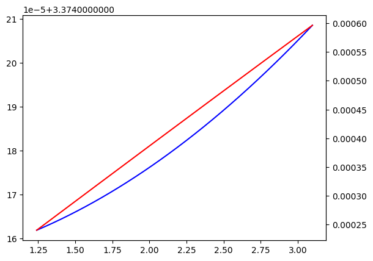

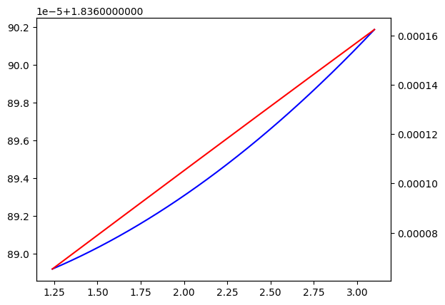

```python
epsilon = [p + h + d for p, h, d in zip(permittivity, harmonic, drude)]
eps_real = [e.real for e in epsilon]
eps_imag = [e.imag for e in epsilon]
fig, ax = plt.subplots(1)
ax2 = ax.twinx()
ax.plot(eV_range, eps_real, 'b')
ax2.plot(eV_range, eps_imag, 'r')
plt.show()
n = [
    np.sqrt((np.sqrt(eps_r ** 2 + eps_i ** 2) + eps_r) / 2)
    for eps_r, eps_i
    in zip(eps_real, eps_imag)]
k = [
    np.sqrt((np.sqrt(eps_r ** 2 + eps_i ** 2) - eps_r) / 2)
    for eps_r, eps_i
    in zip(eps_real, eps_imag)]
fig, ax = plt.subplots(1)
ax2 = ax.twinx()
ax.plot(eV_range, n, 'b')
ax2.plot(eV_range, k, 'r')
plt.show()
```

- Ok, so that doesn't look right, in fact the other version that we did looked better.
- So, obviously, the harmonic oscillator model should probable be considered in eV. The coefficients are all given in eV or without units, so why would they not be in eV.
- But the Drude model looks very unusual here. Where has the hbar come from? And why is it squared?
- Let's just break it down and make sure that what we think these models are doing, is what they are supposed to be doing, because that was all very very quick.
- First, the infinity epsilon and the poles are, they are just giving us an $\varepsilon_{\infty}$, which we know should be around the high 3-4 range.
- But that parameter is in eV no?
- The manual talks about a $\varepsilon l$ parameter, which doesn't make sense.
- Let's just start with the harmonic oscillator.
- The old model I used gave:

$$\varepsilon(\omega)=\frac{AmpEn}{En^{2}-\omega^{2}-i\omega Br}$$

- Which looks a lot different to the:

$$\varepsilon_{harmonic}=\frac{Amp_{n}Br_{n}}{2}(\frac{1}{En_{n}-E-i\frac{Br_{n}}{2}}+\frac{1}{En_{n}+E-i\frac{Br_{n}}{2}})$$

- So which one is which, and why is it giving such different results. Obviously, we shouldn't be using omega for an energy oscillator, so that can be changed for sure. But then what?

```python
test = f'{En} - {complex(eV_range[0], -Br/2)}'
print(test)
operator_plus = [complex(En + e, -Br/2) for e in eV_range]
operator_nega = [complex(En - e, -Br/2) for e in eV_range]
print(operator_plus)
print(operator_nega)
sum_brackets = [p + n for p, n in zip(operator_plus, operator_nega)]
print(sum_brackets)
amplitude = (Amp * Br) / 2
print(amplitude)
final = [amplitude * b for b in sum_brackets]
print(final)
print(harmonic)
```

```
0.0102 - (3.0996049608300065-50j)
[(3.1098049608300067-50j), (3.102075272648386-50j), (3.094384040626872-50j), (3.0867309784913215-50j), (3.0791158028019865-50j), (3.071538232918525-50j), (3.063997990965524-50j), (3.0564948017985323-50j), (3.049028392970595-50j), (3.041598494699273-50j), (3.0342048398341523-50j), (3.026847163824824-…
[(-3.0894049608300063-50j), (-3.0816752726483854-50j), (-3.0739840406268715-50j), (-3.066330978491321-50j), (-3.058715802801986-50j), (-3.0511382329185244-50j), (-3.0435979909655235-50j), (-3.036094801798532-50j), (-3.0286283929705946-50j), (-3.0211984946992727-50j), (-3.013804839834152-50j), (-3.00…
[(0.020400000000000418-100j), (0.020400000000000418-100j), (0.020400000000000418-100j), (0.020400000000000418-100j), (0.020400000000000418-100j), (0.020400000000000418-100j), (0.020400000000000418-100j), (0.020400000000000418-100j), (0.020400000000000418-100j), (0.020400000000000418-100j), (0.020400…
-594.0
[(-12.117600000000248+59400j), (-12.117600000000248+59400j), (-12.117600000000248+59400j), (-12.117600000000248+59400j), (-12.117600000000248+59400j), (-12.117600000000248+59400j), (-12.117600000000248+59400j), (-12.117600000000248+59400j), (-12.117600000000248+59400j), (-12.117600000000248+59400j),…
[(-0.004791513994348526+0.0005963638354153783j), (-0.004791788830567075+0.0005948993330448793j), (-0.0047920616356062744+0.0005934419493479684j), (-0.004792332429389921+0.0005919916329641048j), (-0.004792601231598116+0.0005905483330355954j), (-0.004792868061671773+0.0005891119991808039j), (-0.004793…
```

- So for whatever reason there it seems the final and harmonic parameters differ wildly, let's see if that's the case for the Drude oscillator.

```python
brackets = [complex(t * (e ** 2), (const.hbar * e)) for e in eV_range]
print(brackets)
denominator = [eps_0 * rho * b for b in brackets]
print(denominator)
numerator = - (const.hbar ** 2)
print(numerator)
final_drude = [numerator / d for d in denominator]
print(final_drude)
print(drude)
```

```
[(59.67249872189754+3.2687560375275436e-34j), (59.37525136972784+3.2606045262120135e-34j), (59.08021952119751+3.2524935696791472e-34j), (58.787381213501746+3.244422866032301e-34j), (58.49671475531568+3.236392116363904e-34j), (58.20819872277765+3.228401024718561e-34j), (57.9218119555413+3.22044929805…
[(3.407794958759741e-13+1.866731004179342e-48j), (3.390819667797828e-13+1.8620758146427348e-48j), (3.3739709004824033e-13+1.8574437852530762e-48j), (3.357247402555021e-13+1.8528347436023243e-48j), (3.340647935260994e-13+1.8482485189894472e-48j), (3.324171275120002e-13+1.8436849423993496e-48j), (3.30…
-1.1121217185735183e-68
[(-3.2634642988563855e-56+1.7876691706606624e-91j), (-3.2798020170025355e-56+1.801110236169898e-91j), (-3.296180528452422e-56+1.8146185068670195e-91j), (-3.3125998332060424e-56+1.8281941503460084e-91j), (-3.3290599312634e-56+1.8418373342008517e-91j), (-3.3455608226244926e-56+1.8555482260255344e-91j)…
[(-3.2634642988563855e-56+1.7876691706606624e-91j), (-3.2798020170025355e-56+1.801110236169898e-91j), (-3.296180528452422e-56+1.8146185068670195e-91j), (-3.3125998332060424e-56+1.8281941503460084e-91j), (-3.3290599312634e-56+1.8418373342008517e-91j), (-3.3455608226244926e-56+1.8555482260255344e-91j)…
```

```python
perm = [Einf + h + d for h, d in zip(final, final_drude)]
print(perm)
print(epsilon)
```

```
[(-8.738600000000249+59400j), (-8.738600000000249+59400j), (-8.738600000000249+59400j), (-8.738600000000249+59400j), (-8.738600000000249+59400j), (-8.738600000000249+59400j), (-8.738600000000249+59400j), (-8.738600000000249+59400j), (-8.738600000000249+59400j), (-8.738600000000249+59400j), (-8.73860…
[(3.3742084860056516+0.0005963638354153783j), (3.374208211169433+0.0005948993330448793j), (3.374207938364394+0.0005934419493479684j), (3.37420766757061+0.0005919916329641048j), (3.374207398768402+0.0005905483330355954j), (3.3742071319383284+0.0005891119991808039j), (3.3742068670611847+0.000587682581…
```

- Ok definitely something weird going on here.

**COME BACK AND FIX THIS LATER**

## Augusto's Data

- Augusto gave me two samples of amorphous silicon on the same substrate and of different thicknesses.
- Fortunately, for one of the samples, I took the VASE refractive index components, so that we can compare.

### Augusto 1

- Let's start with the first sample, for which I have the refractive index components.
- The problem here is that I don't know if these are the fitted refractive index components or the standard model's refractive index components.
- The layer was amorphous silicon, of approximately 450nm, on top of silicon dioxide.
- It was fitted with a Cody-Lorentz oscillator:
  - The Cody-Lorentz oscillator is similar to the Tauc-Lorentz in that it defines a bandgap energy *$E_{g}$* and a Lorentzian absorption peak (parameters Amp, Eo, and Br).
  - However, for the Cody-Lorentz $\varepsilon_{2}(E)$ is proportional to $(E-E_{g})^{2}$ in the region just above $E_{g}$.
  - The Cody-Lorentz also defines two transition energies: $E_{p}$ and $E_{t}$.
  - $E_{p}$ is where absorption transitions from Lorentzian to Cody behaviour, and $E_{t}$ is where the absorption transitions from Cody to Urbach behaviour.
- The text is a lot more confusing than that, so let's just see what parameters we have first and work through the model from there.

```python
wavelength_range = range(400, 1001, 1)
wavelength_m = [x * 1E-9 for x in wavelength_range]
energy_range = [(const.h * const.speed_of_light) / x for x in wavelength_m]
eV_range = [E / const.elementary_charge for E in energy_range]

Einf = 2.542
UV_amp = 66.5328
UV_En = 15
IR_Amp = -7.3036

IR_pole = [(IR_amp) / (0 - e) for e in eV_range]
UV_pole = [(UV_amp) / (UV_En - e) for e in eV_range]
permittivity = [Einf + I + U for I, U in zip(IR_pole, UV_pole)]
print(permittivity)
```

```
[8.132806001061995, 8.129176950471614, 8.12557062804956, 8.121986820947985, 8.118425318968502, 8.114885914521103, 8.111368402583823, 8.10787258066314, 8.104398248755134, 8.100945209307332, 8.097513267181267, 8.094102229615714, 8.09071190619061, 8.087342108791605, 8.083992651575276, 8.080663350934962…
```

- Well, this time we have the IR and UV poles and we actually have some level of dispersion.
- Let's see what it looks like.

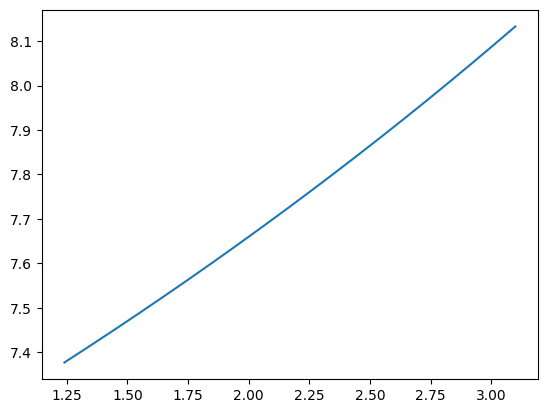

```python
fig, ax = plt.subplots(1)
ax.plot(eV_range, permittivity)
plt.show()
```

- Well that is a start, the permittivity is quite high, but that's sort of what I expected.
- This would give a refractive index around the 2-3 mark.
- In fact, let's see it.

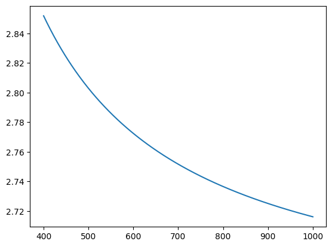

```python
n = np.sqrt(permittivity)
fig, ax = plt.subplots(1)
ax.plot(wavelength_range, n)
plt.show()
```

- So yeah, not bad.
- The Cody-Lorentz model then gives a value for $\varepsilon_{2}$ in a certain region.
- This region depends on the bandgap $E_{g}$ and some function Gamma, but for now i think we just consider the other parameters.
- The simple Cody-Lorentz model that we have is:

$$\varepsilon_{2}(E)=\frac{E_{1}}{E}e^{\frac{E-E_{gn}-E{tn}}{E_{un}}}$$

- But we don't actually know the transition energy $E_{t}$ which is where the absorption transitions from Cody to Urbach.
- We could assume that that value is very large and see what happens.
- Or we could try using the Tauc-Lorentz equation because the Lorentz equation does not include many of the parameters that we have to consider here.
- Let's also try the $\varepsilon \alpha (E-E{g})^{2}$ relationship, because why not.

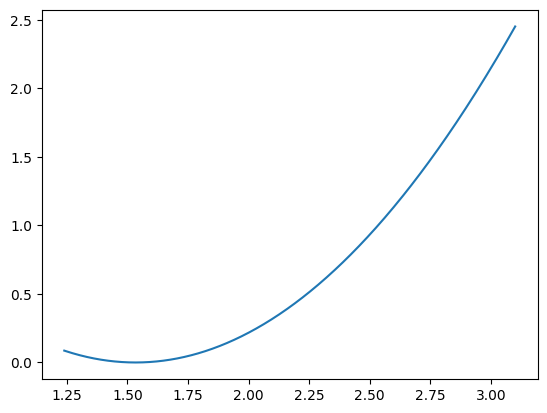

```python
Amp = 64.22
Br = 1.394
Eo = 3.406
Eg = 1.534
Ep = 1.998

prop_absorption = [(E - Eg) ** 2 for E in eV_range]
fig, ax = plt.subplots(1)
ax.plot(eV_range, prop_absorption)
plt.show()
```

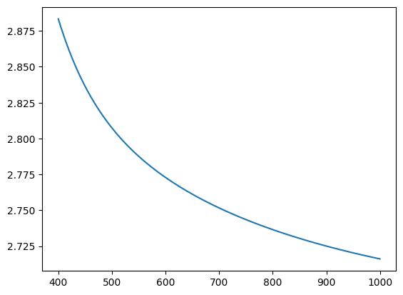

```python
n = [
    np.sqrt((np.sqrt(eps_r ** 2 + eps_i ** 2) + eps_r) / 2)
    for eps_r, eps_i
    in zip(permittivity, prop_absorption)]
fig, ax = plt.subplots(1)
ax.plot(wavelength_range, n)
plt.show()
```

- That's not quite what the ellipsometer thinks it is.
- Let's try something else.

```
[10.648862890820187, 10.523816683077907, 10.39865704692667, 10.27348542870694, 10.148398565075281, 10.023488513326921, 9.89884269710824, 9.774543966030448, 9.650670667739126, 9.527296731045553, 9.404491758784125, 9.282321129122815, 9.160846104120802, 9.040123944397331, 8.920208028846554, 8.801147978…
```

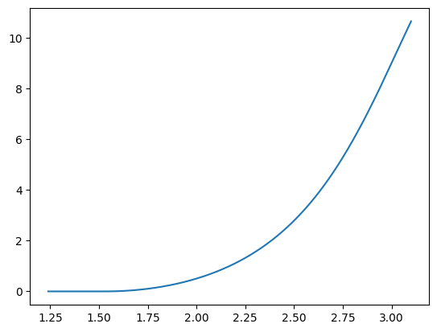

```
[(8.132806001061995+10.648862890820187j), (8.129176950471614+10.523816683077907j), (8.12557062804956+10.39865704692667j), (8.121986820947985+10.27348542870694j), (8.118425318968502+10.148398565075281j), (8.114885914521103+10.023488513326921j), (8.111368402583823+9.89884269710824j), (8.10787258066314…
```

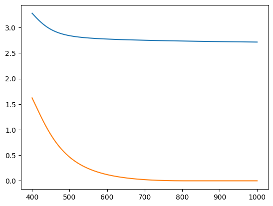

```python
tauc = []
for e in eV_range:
    if e > Eg:
        eps = ((Amp * Eo * Br * ((e - Eg)**2))/((((e**2) - (Eo**2))**2) + (Br**2) * (e**2))) * (1 / e)
        tauc.append(eps)
    else:
        tauc.append(0)
print(tauc)
fig, ax = plt.subplots(1)
ax.plot(eV_range, tauc)
plt.show()
complex_permittivity = [complex(n, k) for n, k in zip(permittivity, tauc)]
print(complex_permittivity)
eps_real = [e.real for e in complex_permittivity]
eps_imag = [e.imag for e in complex_permittivity]
n = [
        np.sqrt((np.sqrt(eps_r ** 2 + eps_i ** 2) + eps_r) / 2)
        for eps_r, eps_i
        in zip(eps_real, eps_imag)]
k = [
        np.sqrt((np.sqrt(eps_r ** 2 + eps_i ** 2) - eps_r) / 2)
        for eps_r, eps_i
        in zip(eps_real, eps_imag)]
fig, ax = plt.subplots(1)
ax.plot(wavelength_range, n)
ax.plot(wavelength_range, k)
plt.show()
```

- That is actually much closer to what I expect from the VASE system.
- The data closely resembles the form of the data, but obviously there is still something missing.
- Without having the model in front of me, I cannot plot the Urbach energy business.
- So I think this is as far as it can go until the software can be obtained.

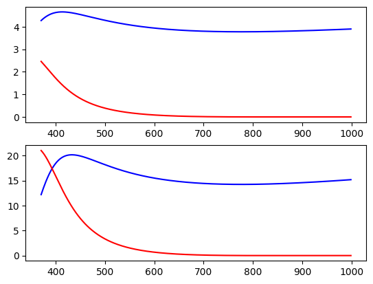

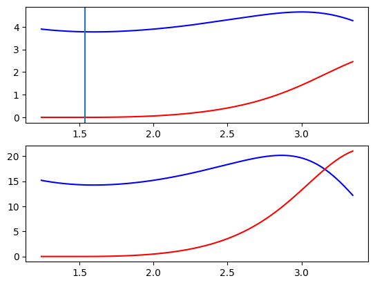

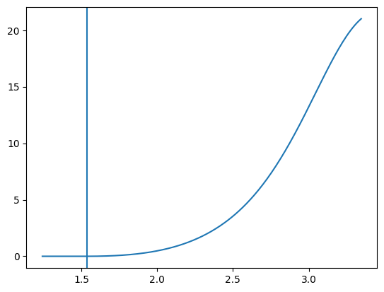

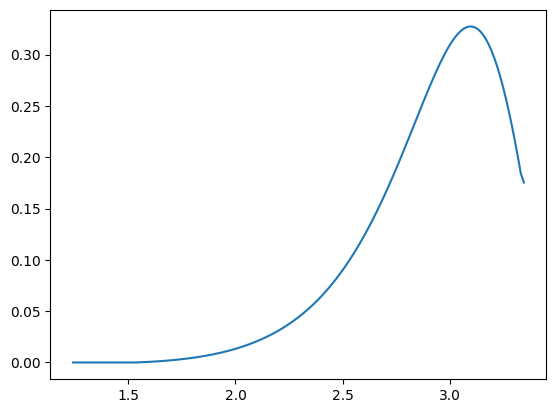

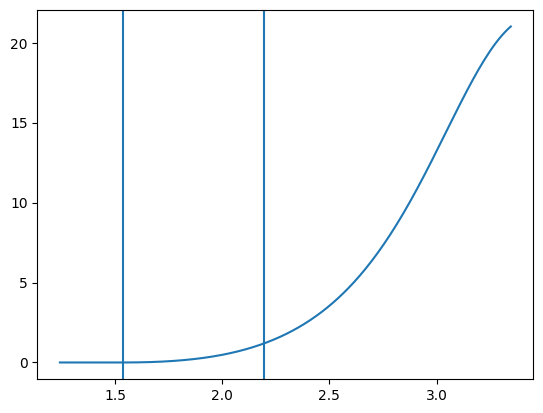

```
0.6609587992089121
```

```python
wavelength, n, k = np.genfromtxt('test.txt', delimiter='\t', unpack=True)
wavelength_m = [x * 1E-9 for x in wavelength]
energy_range = [(const.h * const.speed_of_light) / x for x in wavelength_m]
eV_range = [E / const.elementary_charge for E in energy_range]
eps_real = [(a**2) - (b**2) for a, b in zip(n, k)]
eps_imag = [2 * a * b for a, b in zip(n, k)]
fig, (ax1, ax2) = plt.subplots(2)
ax1.plot(wavelength, n, 'b')
ax1.plot(wavelength, k, 'r')
ax2.plot(wavelength, eps_real, 'b')
ax2.plot(wavelength, eps_imag, 'r')
plt.show()

fig, (ax1, ax2) = plt.subplots(2)
ax1.plot(eV_range, n, 'b')
ax1.plot(eV_range, k, 'r')
ax2.plot(eV_range, eps_real, 'b')
ax2.plot(eV_range, eps_imag, 'r')
ax1.axvline(x=Eg)
plt.show()

fig, ax = plt.subplots(1)
ax.plot(eV_range, eps_imag)
ax.axvline(x=Eg)
plt.show()

gradient = np.gradient(f=eps_imag[::-1])
fig, ax = plt.subplots(1)
ax.plot(eV_range, gradient[::-1])
plt.show()


indices = []
for i, g in enumerate(eps_imag[::-1]):
    if g>0:
        indices.append(i)
min_index = min(indices)
min_energy = eV_range[min_index]

fig, ax = plt.subplots(1)
ax.plot(eV_range, eps_imag)
ax.axvline(x=Eg)
ax.axvline(x=min_energy)
plt.show()

Et = min_energy - Eg
print(Et)
```

- Perhaps that is a way to find the $E_{t}$ transition energy.
- It feels a bit janky, and perhaps the best way is to go back into the software and refit the model.
- But that could take some time as we are still waiting on a copy of the software from Sheffield.
- In this instance, we would need to know $E_{u}$ or $E_{\mu}$, as it is sometimes noted.
- This parameter comes from the Urbach parameters and determines the decay of the imaginary component of the dielectric.
- There exists a paper on it, but that's not super clear and it's probably better to have the model in the VASE software to get this done properly.
- I think it is probably ok to assume that the n, k parameters are as they are in the model, but it would be nice to verify this.

## Soheila's Samples

- Finally let's look at Soheila's samples, or at least the ones that were fitted with other models.
- Soheila gave me several samples, some amorphous silicon on calcium fluoride, and some amorphous silicon on QCM sensors.
- The amorphous silicon on QCM sensors were fitted using the Cody-Lorentz model, where it is becoming apparent that we need to know the Urbach parameters, but the others were fitted using the Tauc Lorentz, so let's look at those.

### aSi CaF<sub>2</sub>

- The samples of amorphous silicon on calcium fluoride, there were 2, were of different thicknesses.
- It is not clear yet whether the thickness parameter in the model is used to affect the dispersion curve, but let's begin with the first sample and see what we get.
- Fortunately, again, this has been used to plot the n and k from the software, so hopefully we can verify the Tauc-Lorentz model somewhat.

```python
Einf = 2.033
UV_amp = 37.6569
UV_En = 11.360
IR_amp = 0.7464
amp = 21.3130
Br = 0.890
Eo = 3.723
Eg = 1.244

wavelength_range = range(400, 1001, 1)
wavelength_m = [x * 1E-9 for x in wavelength_range]
energy_range = [(const.h * const.speed_of_light) / x for x in wavelength_m]
eV_range = [E / const.elementary_charge for E in energy_range]

IR_pole = [(IR_amp) / (0 - e) for e in eV_range]
print(IR_pole)
UV_pole = [(UV_amp) / (UV_En - e) for e in eV_range]
print(UV_pole)
permittivity = [Einf + I + U for I, U in zip(IR_pole, UV_pole)]
print(permittivity)
```

```
[-0.24080487979349804, -0.2414068919929818, -0.24200890419246557, -0.24261091639194932, -0.24321292859143306, -0.2438149407909168, -0.2444169529904005, -0.24501896518988428, -0.245620977389368, -0.24622298958885175, -0.24682500178833555, -0.24742701398781924, -0.24802902618730302, -0.248631038386786…
[4.558728707457044, 4.554466852130083, 4.550234101973966, 4.5460301598546335, 4.5418547326688845, 4.537707531276264, 4.533588270432312, 4.529496668723164, 4.525432448501472, 4.521395335823586, 4.5173850603880155, 4.513401355475094, 4.509443957887841, 4.505512607894009, 4.5016070491692455, 4.49772702…
[6.3509238276635465, 6.346059960137101, 6.3412251977815, 6.336419243462684, 6.331641804077451, 6.326892590485347, 6.322171317441912, 6.31747770353328, 6.312811471112104, 6.308172346234734, 6.30356005859968, 6.298974341487274, 6.294414931700538, 6.289881569507223, 6.285373998582974, 6.280891965955635…
```

- The equation for the Tauc-Lorentz oscillator is:

$$\varepsilon_{T-L}(E)=\varepsilon_{n1} + i \varepsilon_{n2}$$

Where

$$\varepsilon_{n2}=[\frac{Amp_{n}Eo_{n}Br_{n}(E-Eg_{n})^{2}}{(E^{2}-Eo_{n}^{2})^{2}+Br_{n}^{2}E^{2}}\frac{1}{E}] for E>Eg_{n}$$ $$\varepsilon_{n2}=0 for E \leq Eg_{n}$$

- Where there is another example of the Kramers-Kronig integral presented in Jellison and Modine for the $\varepsilon_{n1}$ parameter.
- Still not quite sure what this integral is or does or even how to type it in LaTeX/Markdown so that's why it has been left out here.

```python
tauc = []
for e in eV_range:
    if e > Eg:
        epsilon = ((Amp*Eo*Br*((e-Eg)**2))/(((e**2 - Eo**2)**2)+(Br**2)*(e**2))) * (1/e)
    else:
        epsilon = 0
    tauc.append(epsilon)
print(tauc)
```

```
[9.197940285979787, 9.01397952404757, 8.834908641644958, 8.660580180329031, 8.490850602446645, 8.325580298571033, 8.16463357782678, 8.007878643511967, 7.855187556161225, 7.706436185954256, 7.561504156159084, 7.420274779104695, 7.282634986003359, 7.148475251786596, 7.017689515977559, 6.89017510049780…
```

- That's obviously not possible given that the pole permittivity is so very low.
- So let's see if we can put this integral into practice and see what we get.

```python
A = Amp
print(f'A = {A}')

C = Br
print(f'C = {C}')

print(f'Eo = {Eo}')
gamma = np.sqrt(abs((Eo**2 - ((C**2)/2))))
print(f'Gamma = {gamma}')

alpha = np.sqrt(abs(4 * (Eo**2) - C**2))
print(f'alpha = {alpha}')

def chi(E, gamma, alpha, C):
    return (E**2 - gamma**2)**2 + ((alpha**2 * C**2)/4)

test_chi = [chi(e, gamma, alpha, C) for e in eV_range]
print(f'Test Chi = {test_chi}')

def a_atan(E, Eo, Eg, C):
    return (E**2 - Eo**2)*(Eo**2 + Eg**2) + (Eg**2 * C**2)

test_a_atan = [a_atan(e, Eo, Eg, C) for e in eV_range]
print(f'Test a_atan = {test_a_atan}')

def a_in(Eg, Eo, E, C):
    return (Eg**2 - Eo**2)*(E**2) + (Eg**2 * C**2) - (Eo**2)*(Eo**2 + 3 * Eg**2)

test_a_in = [a_in(Eg, Eo, e, C) for e in eV_range]
print(f'Test a_in = {test_a_in}')

def first_function(Eo, Eg, a, A, C, E, g):
    logarithm = np.log(
        (Eo**2 + Eg**2 + (a * Eg)) / (Eo**2 + Eg**2 - (a * Eg)))
    fractions = (
        (1/2) * (A/np.pi) * (C/(chi(E, g, a, C) ** 4)))
    return fractions * logarithm

test_first = [first_function(Eo, Eg, alpha, A, C, e, gamma) for e in eV_range]
print(f'Test First = {test_first}')

def second_function(A, Eo, Eg, a, C, E):
    fractions = (
        (A/(np.pi * (chi(E, g, a, C) ** 4))) * (a_atan(E, Eo, Eg, C)/Eo))
    brackets = np.pi - np.arctan((2* Eg + a) / C) + np.arctan((-2 * Eg + a)/C)
    return fractions * brackets

test_second = [second_function(A, Eo, Eg, alpha, C, e) for e in eV_range]
print(f'Test Second = {test_second}')

def third_function(A, Eo, C, E, g, a, Eg):
    fraction = 2 * ((A*Eo*C)/(np.pi * (chi(E, g, a, C) ** 4)))
    brackets = (
        (Eg * (E**2 - g**2)) * (np.pi + 2 * np.arctan((g**2 - Eg**2)/(a * C))))
    return fraction * brackets

test_third = [third_function(A, Eo, C, e, gamma, alpha, Eg) for e in eV_range]
print(f'Test Third = {test_third}')

def fourth_function(A, Eo, C, E, Eg, g, a):
    fractions = (
        2 * (A*Eo*C/(np.pi * (chi(E, g, a, C)**4))) * ((E**2 + Eg**2)/E))
    logarithm = np.log((abs(E-Eg))/(E+Eg))
    return fractions * logarithm

test_fourth = [fourth_function(A, Eo, C, e, Eg, gamma, alpha) for e in eV_range]
print(f'Test Fourth = {test_fourth}')

def fifth_function(A, Eo, C, Eg, E, g, a):
    fraction = (
        2 * Eg * (A*Eo*C/(np.pi*(chi(E, g, a, C)**4))))
    logarithm = np.log(
        (abs(E-Eg)*(E+Eg))/np.sqrt(
            ((Eo**2 - Eg**2)**2)+(Eg**2*C**2)))
    return fraction*logarithm

test_fifth = [fifth_function(A, Eo, C, Eg, e, gamma, alpha) for e in eV_range]
print(f'Test Fifth = {test_fifth}')

def function(Einf, A, C, Eo, Eg, E, a, g):
    first_part = first_function(Eo, Eg, a, A, C, E, g)
    second_part = second_function(A, Eo, Eg, a, C, E)
    third_part = third_function(A, Eo, C, E, g, a, Eg)
    fourth_part = fourth_function(A, Eo, C, E, Eg, g, a)
    fifth_part = fifth_function(A, Eo, C, Eg, E, g, a)
    result = Einf + first_part - second_part + third_part - fourth_part + fifth_part
    return result

test_funct = [function(Einf, A, C, Eo, Eg, e, alpha, gamma) for e in eV_range]
print(f'Test Function = {test_funct}')
```

```
A = 64.22
C = 0.89
Eo = 3.723
Gamma = 3.669424886818096
alpha = 7.3926190216999546
Test Chi = [25.699664916366075, 26.07114582897824, 26.444387675552214, 26.819317077861108, 27.195862391113586, 27.57395366409161, 27.953522600253706, 28.334502519778013, 28.716828322521053, 29.100436451868568, 29.485264859455036, 29.871252970729927, 30.258341651348857, 30.646473174367777, 31.0355911…
Test a_atan = [-64.30829178797677, -65.0457037945424, -65.77761957390081, -66.5040936114355, -67.22517971904173, -67.94093104509142, -68.65140008422698, -69.35663868698683, -70.05669806926565, -70.75162882161348, -71.44148091837556, -72.12630372667722, -72.80614601525642, -73.48105596314592, -74.151…
Test a_in = [-373.54356513865525, -372.95427774274407, -372.369382541955, -371.7888359954325, -371.2125951005248, -370.64061738482127, -370.0728608983252, -369.5092842057623, -368.9498463790206, -368.3945069897192, -367.8432261019044, -367.2959642648695, -366.7526825060967, -366.2133423243187, -365.…
Test First = [2.8703842430196805e-05, 2.7102503253272634e-05, 2.5604471702714358e-05, 2.4202432704989637e-05, 2.2889617776048725e-05, 2.1659763726977768e-05, 2.050707431358672e-05, 1.9426184665991117e-05, 1.8412128333706857e-05, 1.746030678369395e-05, 1.6566461192562683e-05, 1.5726646379303592e-05, …
Test Second = [-8.879030392212887e-19, -8.972890025775786e-19, -9.065879661322391e-19, -9.158010279289063e-19, -9.249292684877929e-19, -9.339737511429552e-19, -9.429355223719713e-19, -9.518156121182437e-19, -9.606150341060947e-19, -9.693347861488602e-19, -9.779758504501374e-19, -9.865391938983826e-1…
Test Third = [-0.007859071966757288, -0.007512700694445504, -0.007183788294652348, -0.006871422811334871, -0.0065747350232614726, -0.006292897534877547, -0.0060251236811327, -0.005770666290854537, -0.00552881634621742, -0.0052989015697637, -0.005080284965178347, -0.0048723633334945594, -0.0046745657…
Test Fourth = [-0.0009505203595169901, -0.0008983969006752635, -0.0008495972701660983, -0.0008038883863003664, -0.0007610544214967818, -0.0007208955124708868, -0.0006832265609738451, -0.000647876120223155, -0.0006146853621132051, -0.0005835071203207577, -0.0005542050045098274, -0.0005266525809762714…
Test Fifth = [-0.00016525957626660275, -0.00015821235574903, -0.000151516638383091, -0.00014515392902424935, -0.000139106638687104, -0.0001333580578008124, -0.00012789232699516982, -0.00012269440614027385, -0.0001177500422432203, -0.00011304573670227045, -0.00010856871233038449, -0.00010430688048416…
Test Function = [2.025954892658923, 2.0262545863537342, 2.026539896808834, 2.0268115140786467, 2.027070102377324, 2.0273162996835192, 2.02755071762716, 2.027773941607894, 2.0279865311019862, 2.0281890201206383, 2.0283819177881934, 2.028565709013377, 2.0287408552308746, 2.028907795194114, 2.029066945…
```

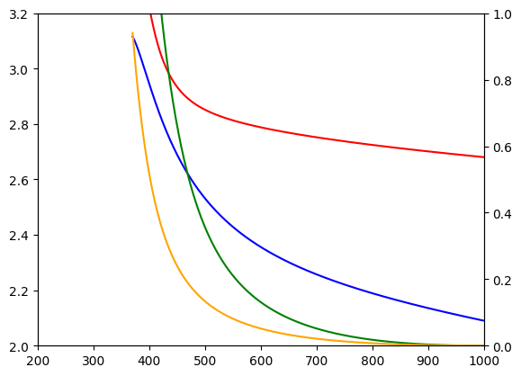

```python
complex_permittivity = [eps + complex(t, e) for eps, t, e in zip(permittivity, test_funct, tauc)]
eps_real = [e.real for e in complex_permittivity]
eps_imag = [e.imag for e in complex_permittivity]
n = [
    np.sqrt((np.sqrt(eps_r ** 2 + eps_i ** 2) + eps_r) / 2)
    for eps_r, eps_i
    in zip(eps_real, eps_imag)]
k = [
    np.sqrt((np.sqrt(eps_r ** 2 + eps_i ** 2) - eps_r) / 2)
    for eps_r, eps_i
    in zip(eps_real, eps_imag)]

wav, ns, ks = np.genfromtxt('test2.txt', delimiter='\t', unpack=True)

fig, ax = plt.subplots(1)
ax2 = ax.twinx()
ax.plot(wavelength_range, n, 'r')
ax.plot(wav, ns, 'b')
ax2.plot(wavelength_range, k, 'g')
ax2.plot(wav, ks, 'orange')
ax.set_ylim(2, 3.2)
ax2.set_ylim(0, 1)
ax.set_xlim(200, 1000)
plt.show()
```

- Well, that is better but it's still not quite right.
- Clearly, I am missing something very important that I have not yet considered.
- More work to be done that's for sure.